# The built in R plots

Dr Juan H Klopper

[figure not shown]

## Data import

```r
library(readr)
library(dplyr)
```

```r
df <- read_csv("ProjectData.csv")
```

```r
names(df)
```

```
## [1] "Age"         "Difference"  "CRP"         "Group"       "sBP"
## [6] "Weight"      "SideEffects" "Survey"
```

## Strip plots

Strp plots are also called dot plots. The represent data point values for a variable along a single axis. It is more common for these plots to visualize discrete numerical variables, but they can also be used for continuous numerical variables and for nominal categorical variable that are expressed as numerical values. The latter is better represented by bar plots, though.

Below, we create a strip plot to visualize *Age* variable as an example of discrete data (since we only captured integer values).

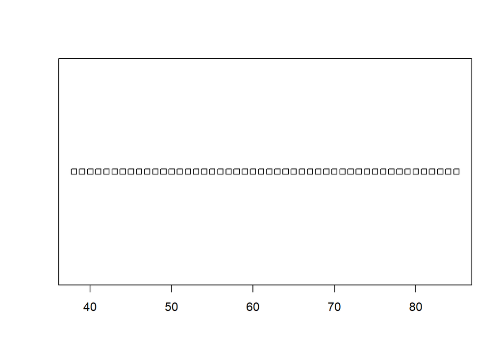

```r
stripchart(df$Age)
```

Our first impression is that this is not a very useful plot. We have $500$ data point value and they all seem to be plotted on top of each other. There is also no title and no *x*-axis label. Let’s start by adding some jitter to the dots to try and visualize all of them. If there are a large number of data point values, this might not solve the problem.

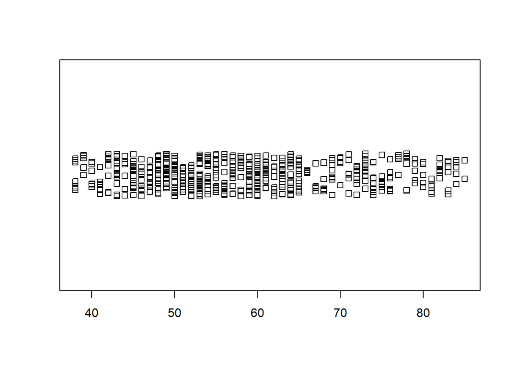

```r
stripchart(df$Age,
           method = "jitter")
```

This is slightly better, but to be honest, a box-and-whisker plot would probably be the default plot for numerical data such as this. Let’s carry on, though, and add a title and a *x*-axis title with the `main =` and the `xlab =` arguments.

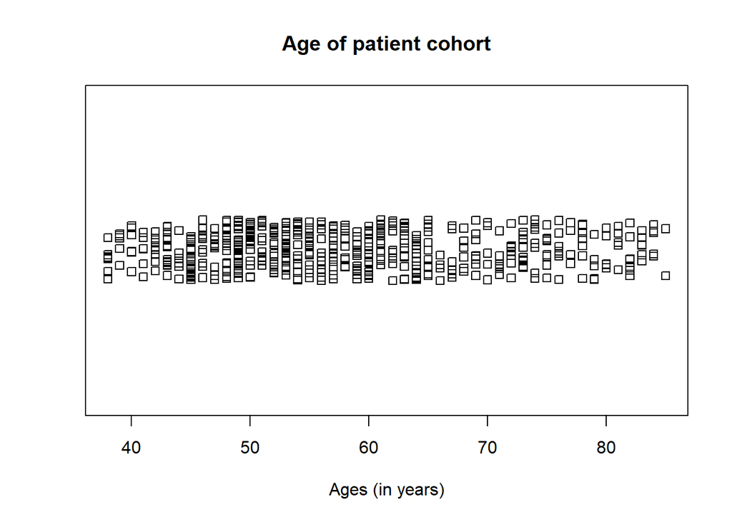

```r
stripchart(df$Age,
           method = "jitter",
           main = "Age of patient cohort",
           xlab = "Ages (in years)")
```

The `method = "stack"` argument creates nice *skyscrapers* instead of the jitter used above. This might be a better option. Let’s see.

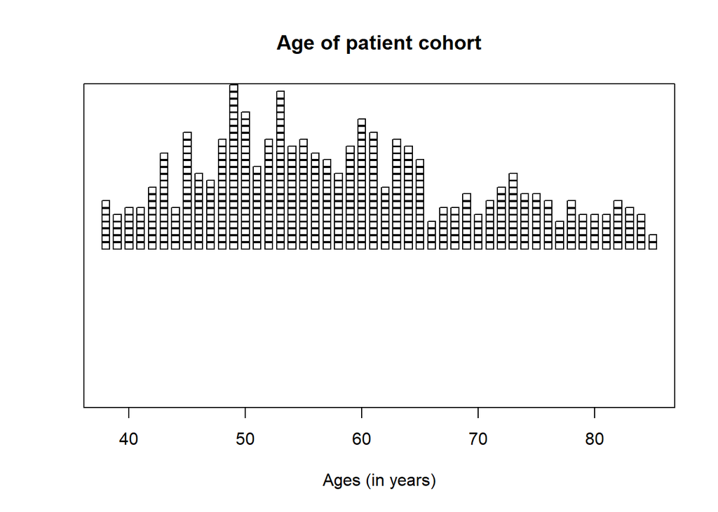

```r
stripchart(df$Age,
           method = "stack",
           main = "Age of patient cohort",
           xlab = "Ages (in years)")
```

In essence this is very much a bar plot, though, so let’s take a look.

## Bar plot

Bar plots give an indication of the number of individual data point values from the sample space of a variable. As such they are excellent for categorical variables, but can also be used for discrete numerical variables. Since both categorical variables and discrete numerical values are well, *discrete*, the bars have gaps between them to indicate that each of items in the sample sapce for the variable is distinct from another. They do not form a continuum as in continuous numerical variables.

They height of each bar indicates the number of times an element from the sample space of a variable appears in the data. There are a number of options for bar plots. Let’s take a look at these and also introduce some new options for plots in R.

### Simple bar plot

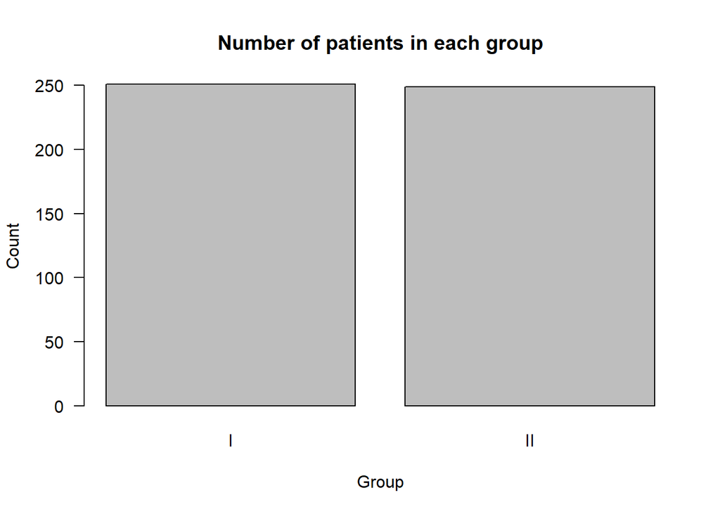

```r
barplot(table(df$Group),
        main = "Number of patients in each group",
        xlab = "Group",
        ylab = "Count",
        las = 1)
```

### Horizonatl bar plot

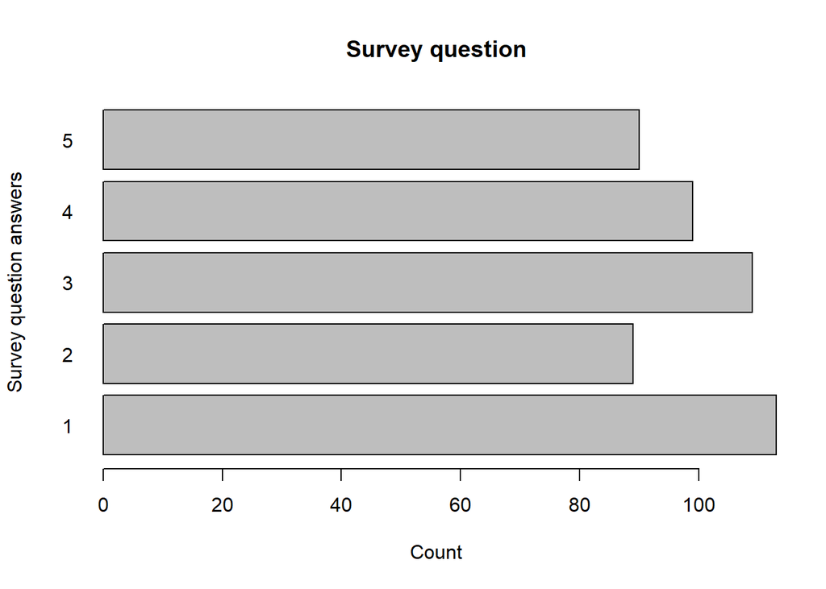

```r
barplot(table(df$Survey),
        main = "Survey question",
        ylab = "Survey question answers",
        xlab = "Count",
        horiz = TRUE,
        las = 1)
```

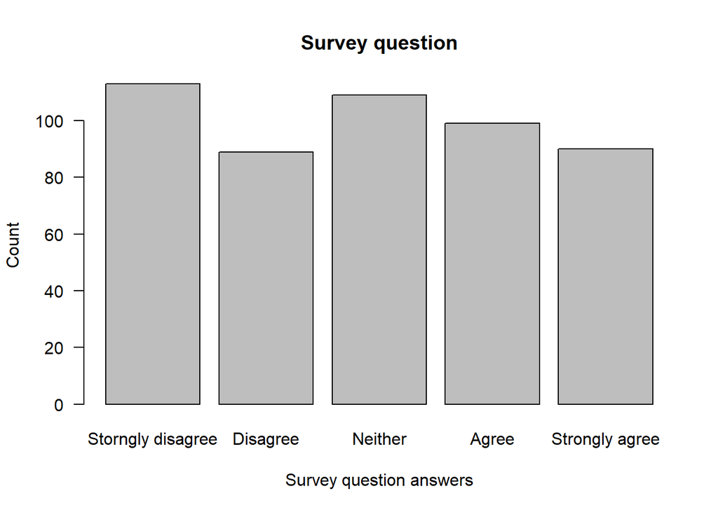

```r
barplot(table(df$Survey),
        main = "Survey question",
        xlab = "Survey question answers",
        ylab = "Count",
        names.arg = c("Storngly disagree",
                      "Disagree",
                      "Neither",
                      "Agree",
                      "Strongly agree"),
        las = 1)
```

### Patterned bar plot

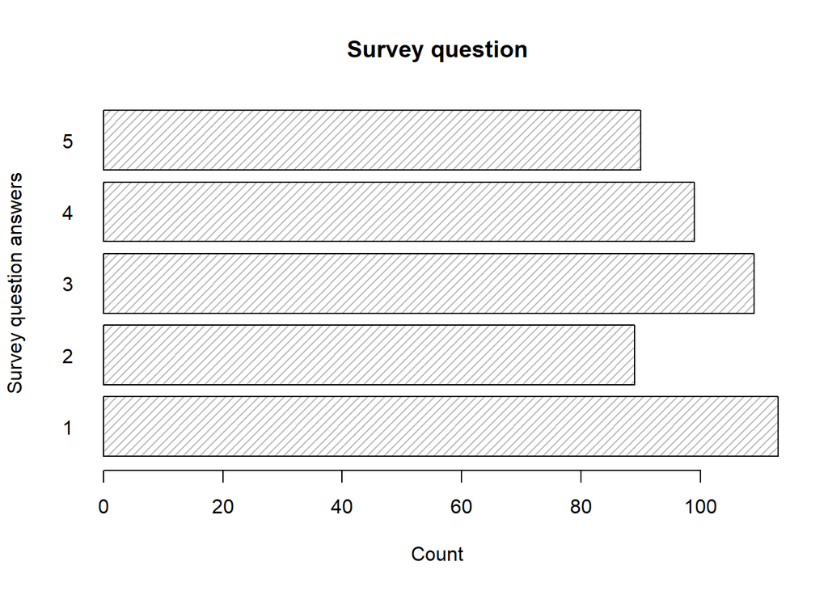

```r
barplot(table(df$Survey),
        main = "Survey question",
        ylab = "Survey question answers",
        xlab = "Count",
        horiz = TRUE,
        border = "black",
        col = "grey",
        density = 20,
        las = 1)
```

### Colored bar plot

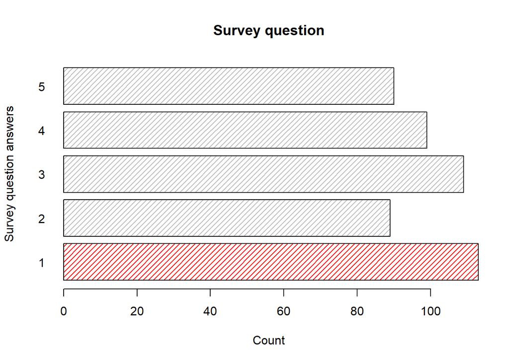

```r
barplot(table(df$Survey),
        main = "Survey question",
        ylab = "Survey question answers",
        xlab = "Count",
        horiz = TRUE,
        border = "black",
        col = c("red", "grey", "grey", "grey", "grey"),
        density = 20,
        las = 1)
```

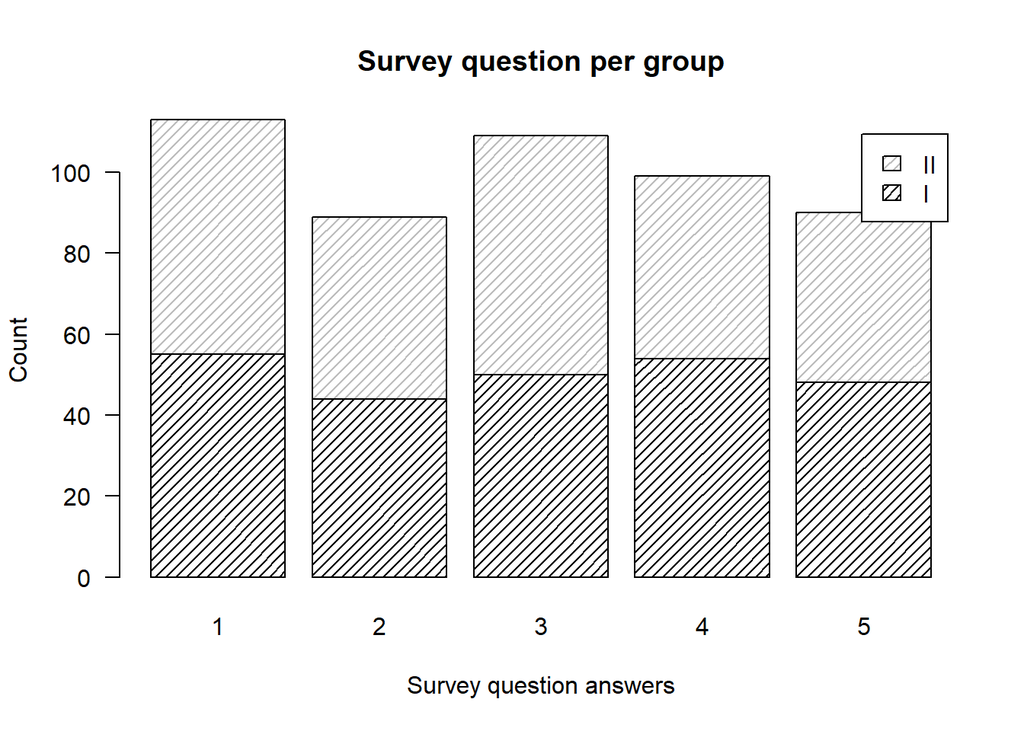

```r
barplot(table(df$Group, df$Survey),
        main = "Survey question per group",
        xlab = "Survey question answers",
        ylab = "Count",
        border = "black",
        col = c("black", "grey"),
        legend = rownames(table(df$Group, df$Survey)),
        density = 20,
        las = 1)
```

### Grouped bar plot

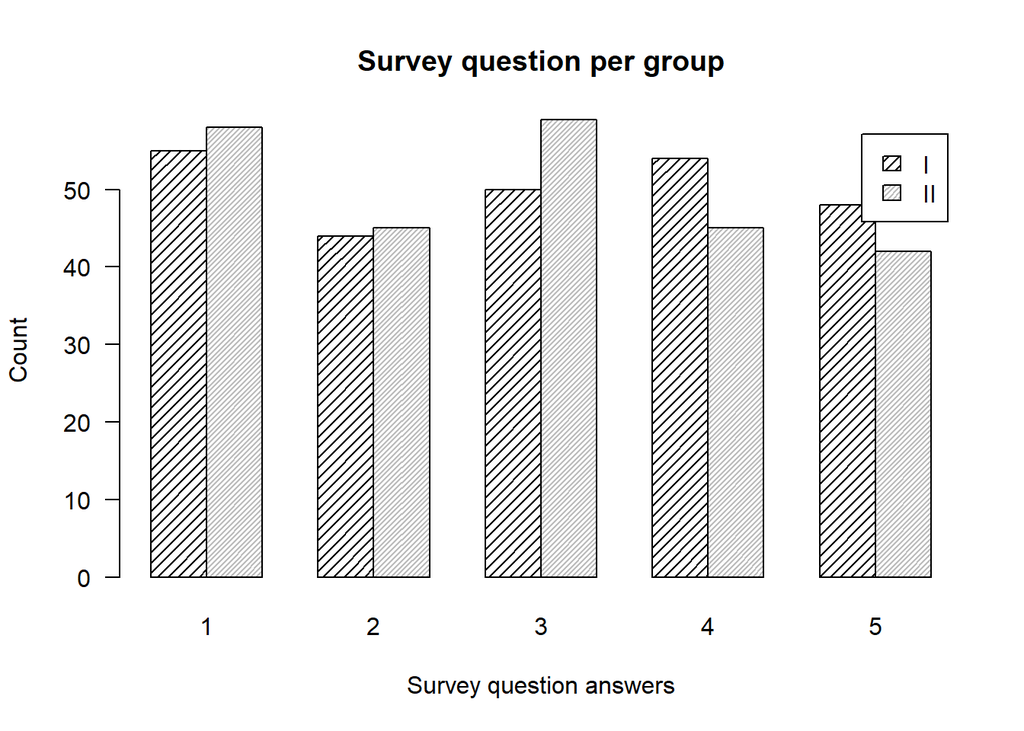

```r
barplot(table(df$Group,
              df$Survey),
        main = "Survey question per group",
        xlab = "Survey question answers",
        ylab = "Count",
        border = "black",
        col = c("black", "grey"),
        legend = rownames(table(df$Group, df$Survey)),
        density = c(20, 40),
        beside = TRUE,
        las = 1)
```

## Histogram

The histogram gives a count of the number of times a value from a continuous numerical variable appears. Since these variables are continuous, though, we have to create *bins*, i.e. lower and upper bounds between which the occurrences are counted. Let’s take a look at an example to make this clear using the `hist()` function.

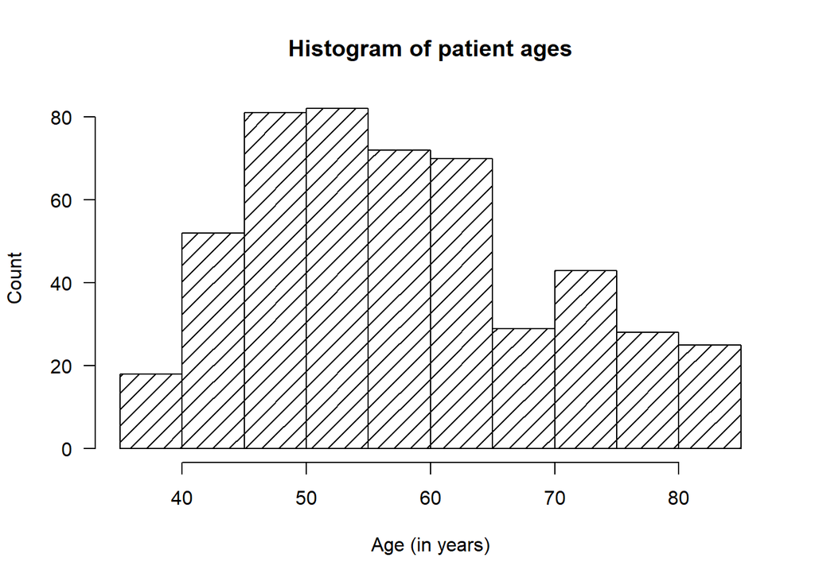

```r
hist(df$Age,
     main = "Histogram of patient ages",
     xlab = "Age (in years)",
     ylab = "Count",
     density = 10,  # Density pattern
     las = 1)
```

It seem as if the default plot created bins in five year intervals so that we ended up with $10$ bins. We can use the `break =` argument to change this behaviour. The value that we pass to this argument wil determin ethe number of bins.

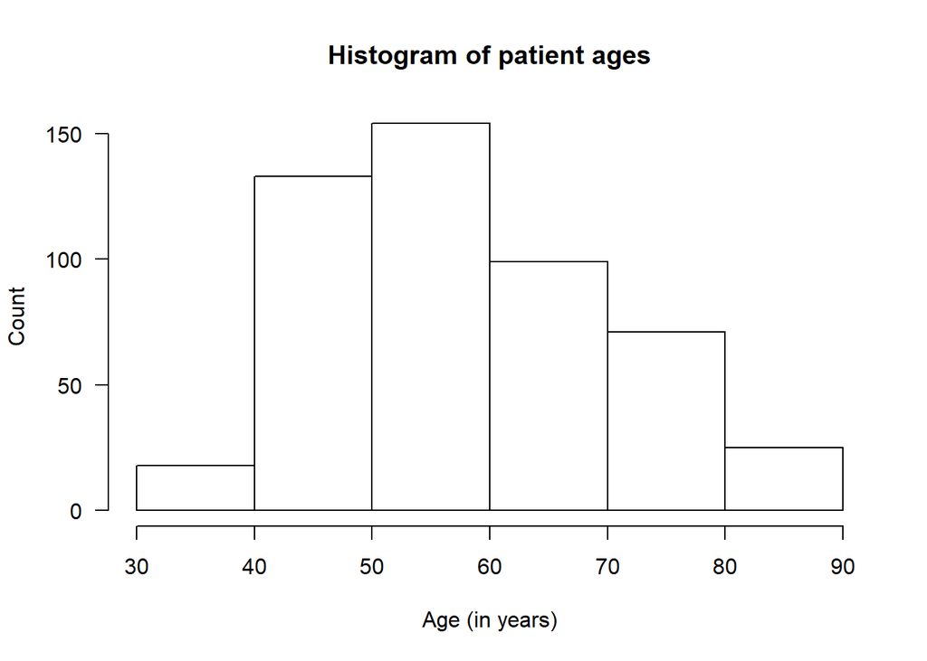

```r
hist(df$Age,
     breaks = 5,
     main = "Histogram of patient ages",
     xlab = "Age (in years)",
     ylab = "Count",
     las = 1)
```

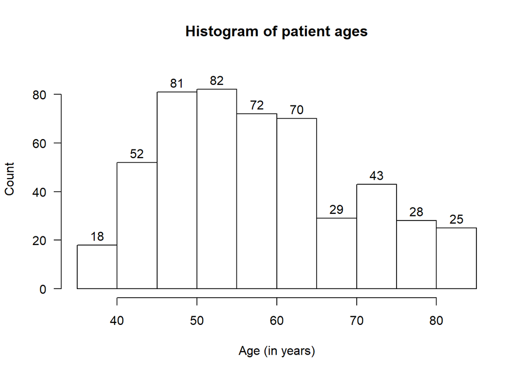

```r
hist(df$Age,
     labels = TRUE,  # Adding labels
     main = "Histogram of patient ages",
     xlab = "Age (in years)",
     ylab = "Count",
     ylim = c(0, 90),
     las = 1)
```

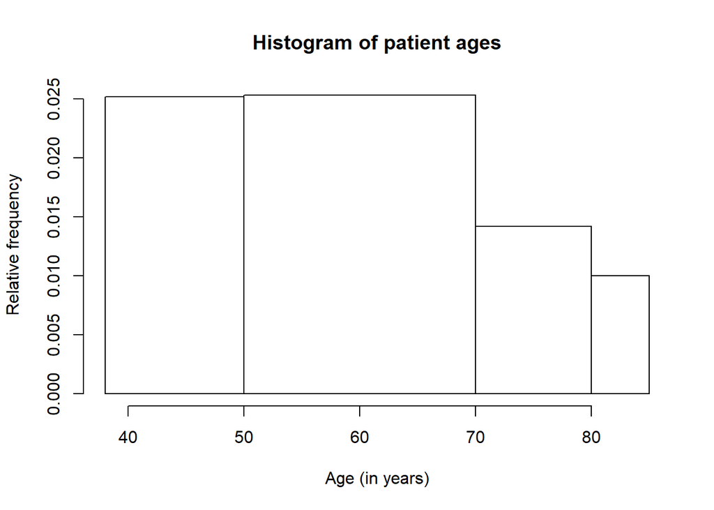

```r
hist(df$Age,
     breaks = c(min(df$Age),50, 70, 80, max(df$Age)),
     main = "Histogram of patient ages",
     xlab = "Age (in years)",
     ylab = "Relative frequency")
```

Under these circumstances, we no longer have a count, but rather a relative frequency (fractional count). This can also be forced with the `freq = FALSE` argument.

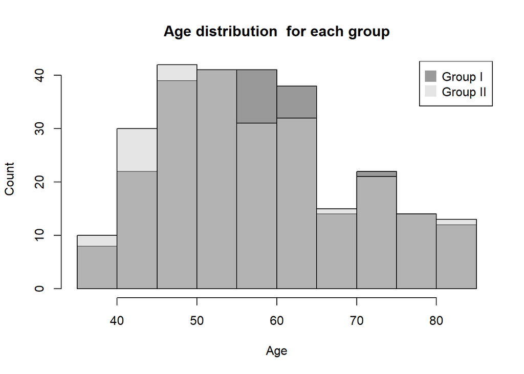

```r
transparent_dark_grey = rgb(0.2, 0.2, 0.2, 0.5)
transparent_light_grey = rgb(0.8, 0.8, 0.8, 0.5)
hist((df %>% filter(Group == "I") %>% select(Age))$Age,
     col = transparent_dark_grey,
     main = "Age distribution  for each group",
     xlab = "Age",
     ylab = "Count")
hist((df %>% filter(Group == "II") %>% select(Age))$Age,
     col = transparent_light_grey,
     add = TRUE)
legend("topright",
       legend = c("Group I", "Group II"),
       col = c(transparent_dark_grey, transparent_light_grey),
       pt.cex = 2,
       pch = 15)
```

## Density plots

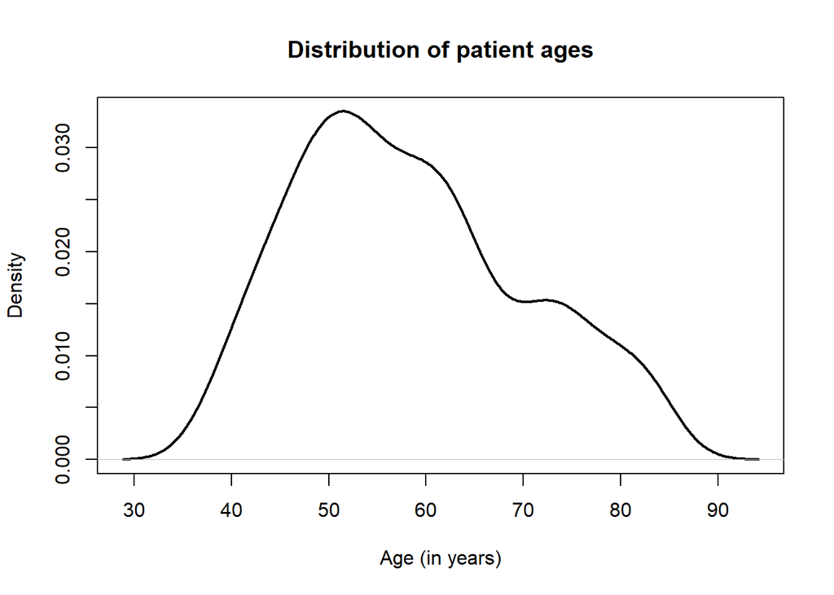

```r
plot(density(df$Age),
     main = "Distribution of patient ages",
     xlab = "Age (in years)",
     ylab = "Density",
     lwd = 2)
```

## Box and whisker plots

These are the most common plots to show the distribution of numerical variables for one or more categorical or discrete groups.

[output not shown]

## Scatter plots

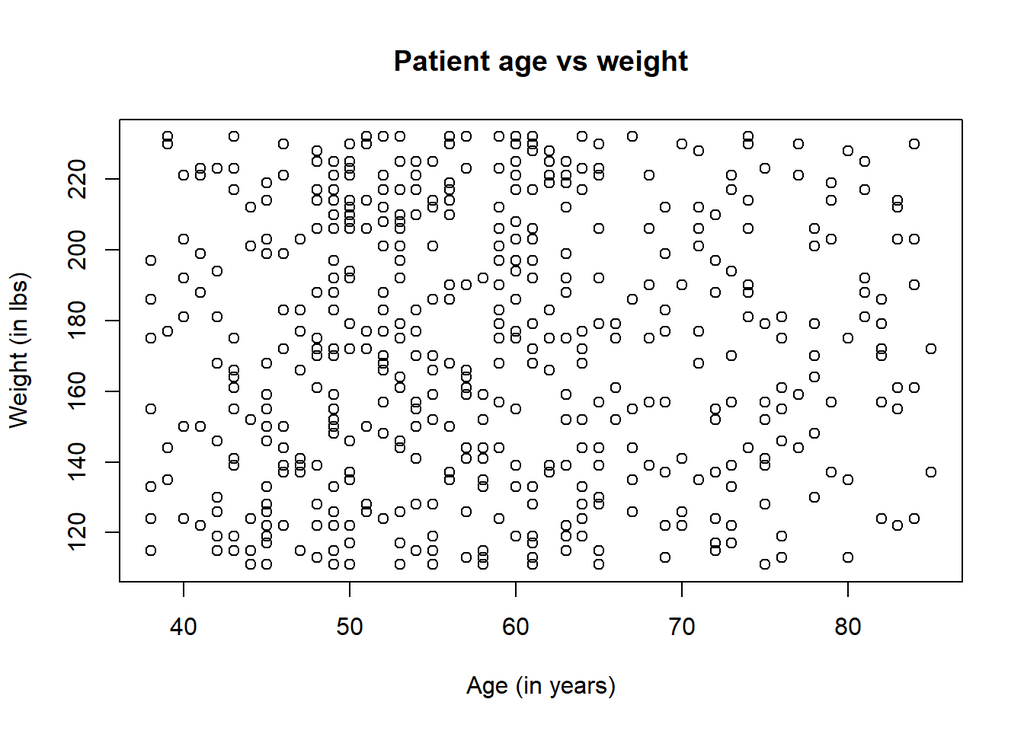

```r
plot(df$Age, # Independent variable (x-axis)
     df$Weight,  # Dependent variable (y-axis)
     main = "Patient age vs weight",
     xlab = "Age (in years)",
     ylab = "Weight (in lbs)")
```

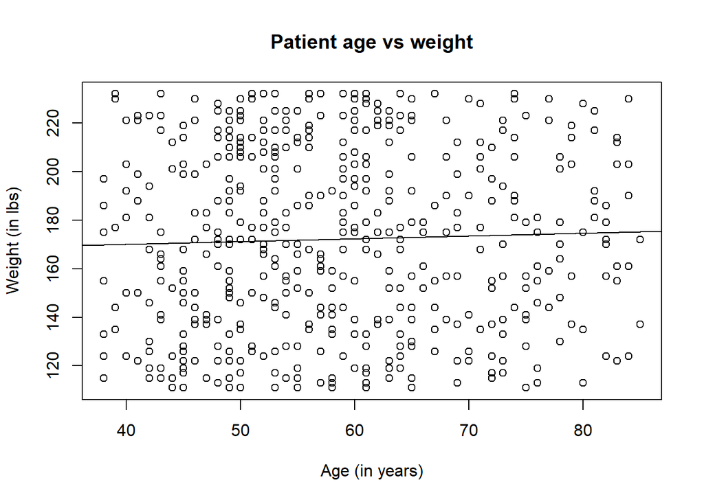

```r
plot(df$Age, # Independent variable (x-axis)
     df$Weight,  # Dependent variable (y-axis)
     main = "Patient age vs weight",
     xlab = "Age (in years)",
     ylab = "Weight (in lbs)")
abline(lm(df$Weight ~ df$Age))
```

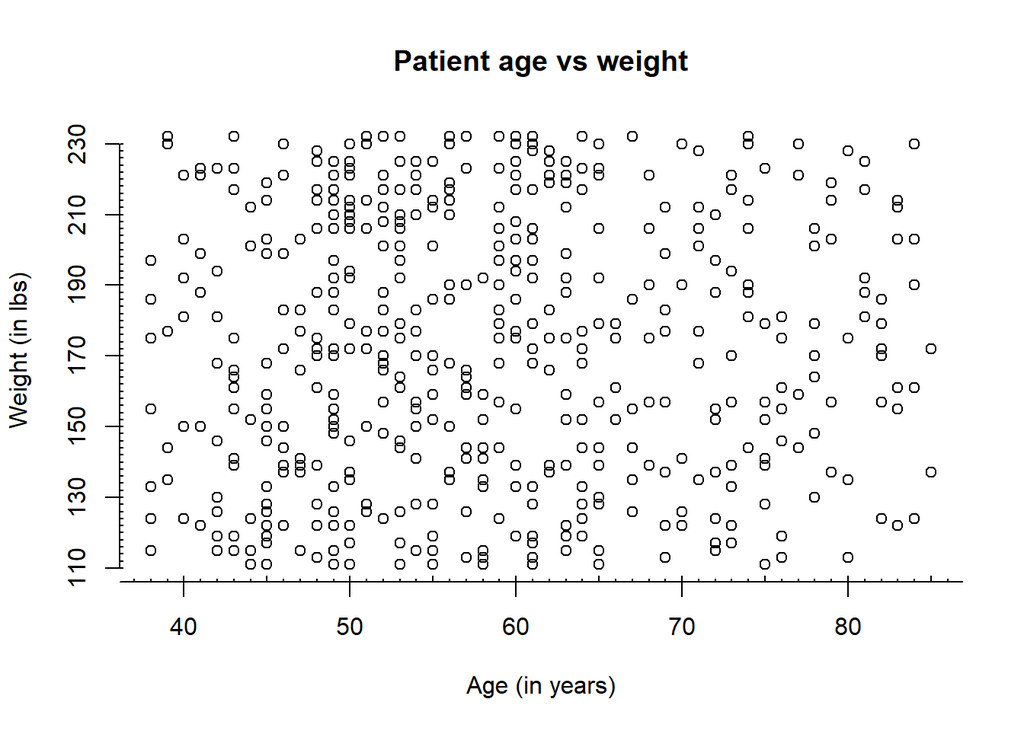

```r
plot(df$Age, # Independent variable (x-axis)
     df$Weight,  # Dependent variable (y-axis)
     main = "Patient age vs weight",
     xlab = "Age (in years)",
     ylab = "Weight (in lbs)",
     axes = FALSE)
# x-axis
# Small tick labels
par(tcl = 0.1)  # Tick length of +0.1 (protruding into plot)
axis(1,
     at = seq(30, 90, by = 1),  # From 30 to 90, stepsize 1
     labels = FALSE)  # Don't add number labels
# Slightly taller tick marks every 5 steps
par(tcl = 0.2)
axis(1,
     at = seq(30, 90, by = 5),
     labels = FALSE)
# MAjor tick marks every 10 years
par(tcl = -0.5)
axis(1,
     at = seq(30, 90, by = 10))
# y-axis
# Small tick marks every 1 lb
par(tcl = 0.1)
axis(2,
     at = seq(110, 230, by = 2),
     labels = FALSE)
par(tcl = -0.5)
axis(2,
     at = seq(110, 230, by = 20))
```

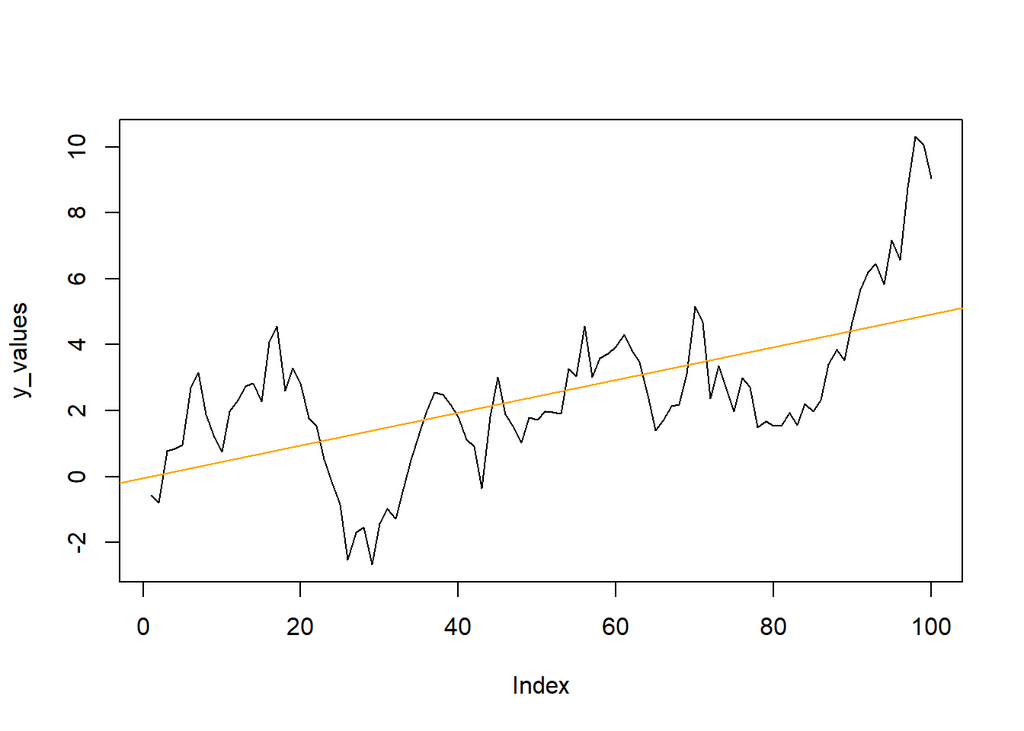

```r
set.seed(123)
x_values = seq(1, 100, by = 1)
y_values = cumsum(rnorm(100))
plot(y_values,
     type = "l")
abline(lm(y_values ~ x_values), col = "orange")
```

## Multiple plots

At times it makes sense to create more than one plot in a figure. R allows for great control over placement of different plot.

A quick note on pie plots: Pie plots are not good at providing accurate visual information, and hence, were not even discussed in this tutorial. Even the help section states the following: *Pie charts are a very bad way of displaying information. The eye is good at judging linear measures and bad at judging relative areas. A bar chart or dot chart is a preferable way of displaying this type of data.*

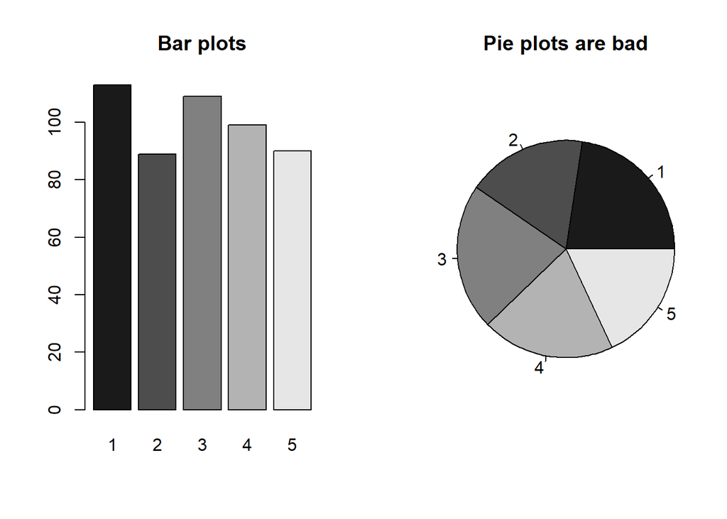

```r
grey_five <- c(rgb(0.1, 0.1, 0.1),
            rgb(0.3, 0.3, 0.3),
            rgb(0.5, 0.5, 0.5),
            rgb(0.7, 0.7, 0.7),
            rgb(0.9, 0.9, 0.9))  # Specifying five shades of grey
par(mfrow = c(1, 2))  # One row, two columns
barplot(table(df$Survey),
        main = "Bar plots",
        col = grey_five)
pie(table(df$Survey),
    main = "Pie plots are bad",
    radius = 1,
    col = grey_five)
```

The graphical parameter fig lets us control the location of a figure precisely in a plot.

We need to provide the coordinates in a normalized form as c(x1, x2, y1, y2). For example, the whole plot area would be c(0, 1, 0, 1) with (x1, y1) = (0, 0) being the lower-left corner and (x2, y2) = (1, 1) being the upper-right corner.

Note: we have used parameters cex to decrease the size of labels and mai to define margins.

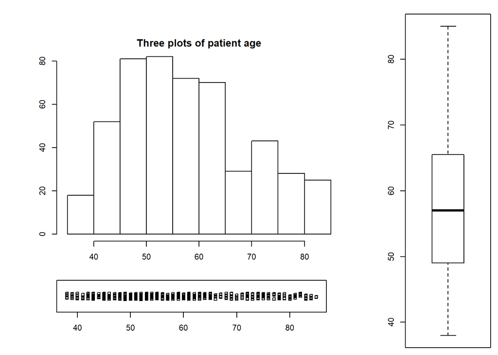

```r
# make labels and margins smaller
par(cex = 0.7, mai = c(0.1, 0.1, 0.2, 0.1))
# define area for the histogram
par(fig = c(0.1, 0.7, 0.3, 0.9))
hist(df$Age,
     main = "Three plots of patient age")
# define area for the boxplot
par(fig = c(0.8 ,1 ,0 ,1 ),
    new = TRUE)
boxplot(df$Age)
# define area for the stripchart
par(fig = c(0.1, 0.67, 0.1, 0.25),
    new = TRUE)
stripchart(df$Age,
           method = "jitter")
```

## Saving plots for your reports

Most manuscripts include plots as figures. Plots created in R can be saved to your computer drive. Below we use the `png()` function to save portable network graphics files. This is a common file type for pictures, with a small file size and good quality.

The `png()` function allows us to specify a picture size (width and height). The default unit is pixels. R also provides for saving in other file types. Look up `bmp`, `jpeg`, and `tiff` in the *Help* tab on the bottom right panel in RStudio.

Once the code for saving the file is complete, remember to use the `dev.off()` function.

```r
png(file = "Fig 1.png",  # Directory or folder set by setwd(getwd())
    width = 600,
    height = 600)
set.seed(1234)
boxplot(rchisq(100, df = 2),
               col = "gold",
        boxwex = 0.4,
        main = "c-Reactive Protein",
        ylab = "CRP")
dev.off()  # Search for dev.off in the Help tab
```